# Project

Author

Caroline, Kim-Linh, Anna, Donya

# Setup and Data Cleaning

## Set Up

(code hidden)

## Cleaning

(code hidden)

## Joining Data

(code hidden)

# Description, Hypothesis, and Explanation of Methods

## Data and Variable Descriptions

Our project incorporates two datasets: `lex.csv` and `hapiscore_whr.csv`. In the lex dataset, the variable “country” lists 195 different countries, and each column represents a year from 1800 to 2100. The values indicate the projected lifespan of newborn infants if mortality rates at different ages remain constant throughout their lives for each country. The data from 1800 to 1970 comes from version 7 by Mattias Lindgren, compiled from 100 sources. For the period 1970 to 2016, the main source is the Institute for Health Metrics and Evaluation (IHME) and their Global Burden of Disease Study. IHME data from 1970 to 2017 was published in September 2017, and data from 2017 to 2100 was sourced from the United Nations’ World Population Prospects 2019. In the happiness score dataset, the “country” column lists 163 different countries, and each year from 2005 to 2022 has a corresponding column. The data set focuses on the “Happiness score” or “Cantril life ladder”, representing the national average response to a life evaluation question. The scale is converted from 0-10 to 0-100 for easier communication. Data is sourced from the World Happiness Report and Gallup World Poll surveys conducted in multiple countries and languages.

## Hypothesis About Variables

We hypothesize that life expectancy will increase with happiness score. This is more of an intuitive belief, as we would expect that with a high percentage of happiness, people in the respective countries would live longer. Of course, this can vary from country to country. It is possible that more developed countries could have a higher happiness score and life expectancy rate, while less developed countries result in the opposite.

# Data Visualization

## Relationship Between Quantitative Variables

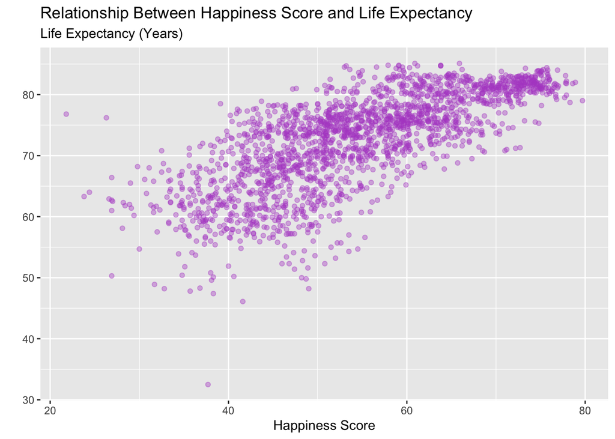

The visualization depicts the relationship between the “Happiness Score” and “Life Expectancy” variables using a scatter plot. The scatter plot shows individual data points as circles, where the x-axis represents the happiness score and the y-axis represents life expectancy. The points are colored in a shade of medium orchid with an alpha value of 0.4, giving them a slightly transparent appearance. The plot exhibits a positive linear trend, indicating that as the happiness score increases, life expectancy tends to be higher.

## Change in Relationship Over Time

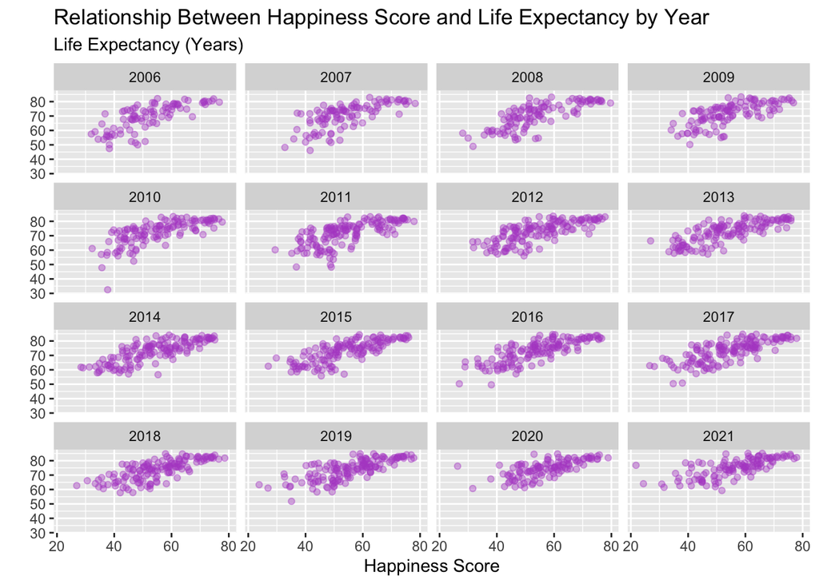

# Linear Regression

## Cleaning `hap_lex` for Linear Regression Analysis

(code hidden)

## Fitting Linear Regression

Simple Linear Regression Fit

| Term | Estimate | Std Error | Statistic | P-value |
| --- | --- | --- | --- | --- |
| (Intercept) | 40.1130860 | 2.0247823 | 19.81106 | 0 |
| avg_hap_score | 0.5872673 | 0.0367898 | 15.96278 | 0 |

## Simple linear regression model

Linear regression is a statistical method that helps us understand and quantify the relationship between variables. It involves finding a straight line that best fits the data points, allowing us to determine how one variable changes when another variable changes. The equation of the line represents the overall trend of the data, with the slope indicating the rate of change and the y-intercept representing the value when the independent variable is zero. By analyzing the data, linear regression enables us to make predictions and estimate values, while also providing insights into the strength and direction of the relationship between the variables. Our model analyzes how the predicted life expectancy changes with the average happiness scores of countries. Our estimated regression equation is:

Predicted life expectancy = 40.113 + 0.587 * (Average happiness score)

In the above model, the intercept of 40.113 indicates someone with an average happiness score of 0 is expected to have a life expectancy of 40 years, on average. The slope of 0.587 represents that for each increase of the happiness score by 1 point, the life expectancy will increase by 0.587 years, on average.

## Model Fit

Model Fit Variance

| Response Variance | Fitted Variance | Residual Variance |
| --- | --- | --- |
| 63.18226 | 38.71835 | 24.46391 |

The response variance represents the overall variability in the observed values of the dependent variable (average life expectancy). In this model, the response variance is measured to be approximately 63.18226. The fitted variance corresponds to the variability in the predicted values of the dependent variable based on the regression model. In this case, the fitted variance is approximately 38.71835. This indicates the amount of variance that can be explained by the independent variable (happiness score) in predicting the life expectancy. Lastly, the residual variance represents the unexplained variability or the differences between the observed values and the predicted values. The residual variance, measured to be approximately 24.46391, signifies the portion of the response variance that is not accounted for by the model. Overall, the fit of the regression model can be assessed by comparing these variances. A good fit would be indicated by a relatively low residual variance compared to the response variance, suggesting that the model explains a significant portion of the observed variability. In this case, the residual variance represents a substantial proportion of the response variance, indicating that there might be other factors beyond happiness score that contribute to the variability in life expectancy.

# Simulations

## Predictive Checks

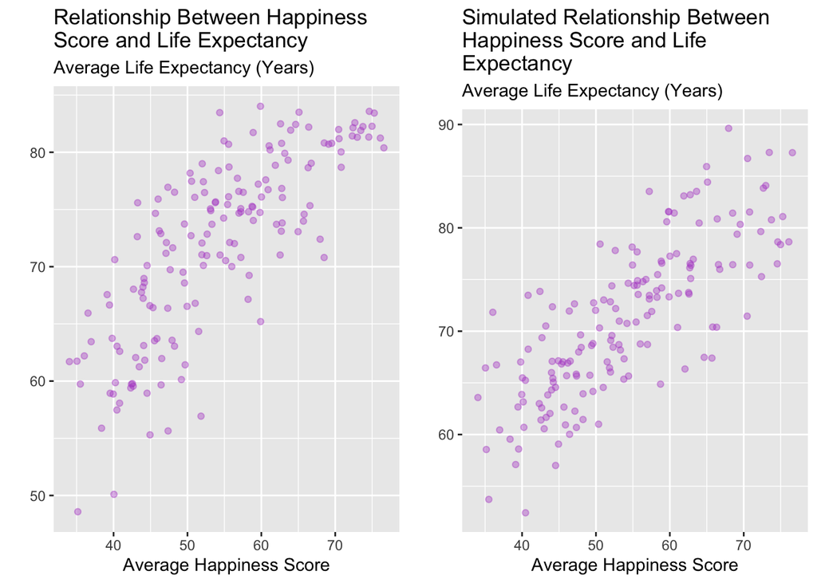

The comparison between the observed and simulated data reveals similarities and differences. Both plots show the relationship between average happiness score and average life expectancy. They share a similar overall average and positive relationship, but we can see a couple of key differences in the two plots. The observed data has a lower minimum life expectancy compared to the simulated data, with the smallest point being 5 years lower than the lowest simulated point, suggesting the inclusion of countries with lower life expectancies. The simulated data appears to have more congestion around the average, indicating greater variability or concentration of points. Additionally, the simulated plot displays a larger maximum life expectancy, being 5 years larger than the maximum life expectancy in the observed data, which could be from extreme values due to the nature of the simulation process.

## References

Data from [gapminder](https://www.gapminder.org/data/)

Var function from [rdocumentation](https://www.rdocumentation.org/packages/cmvnorm/versions/1.0-7/topics/var)